# Normalization performance report

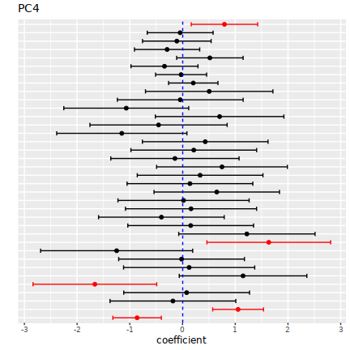

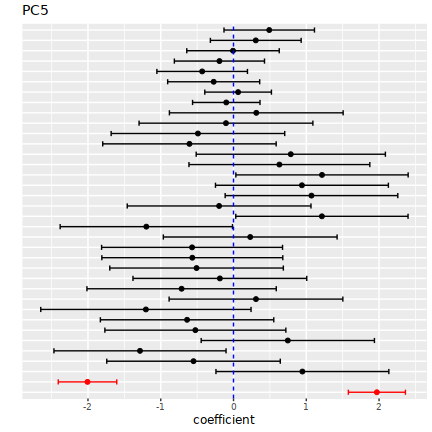

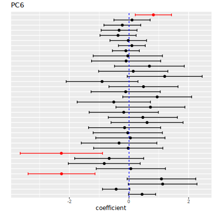

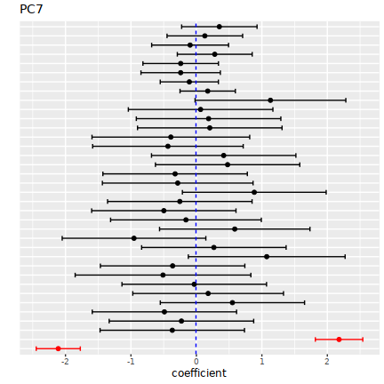

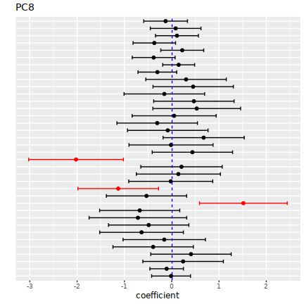

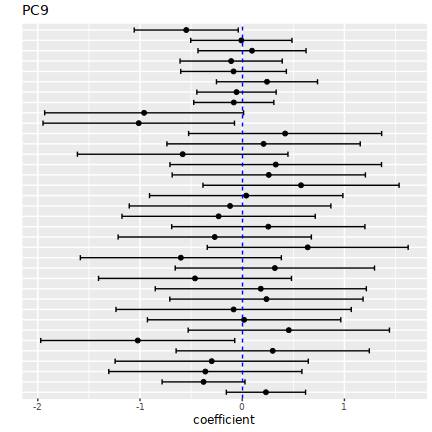

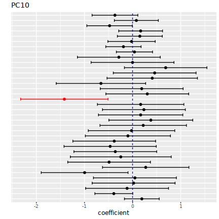

| batch.variable | batch.value | principal.component | test | p.value | estimate | lower | upper |
| --- | --- | --- | --- | --- | --- | --- | --- |
| Sex |  | PC1 | F-test | 2.47e-03 | 9.319 |  |  |
| Sex | F | PC1 | t-test | 2.47e-03 | -1.302 | -2.227 | -0.376 |
| Sex | M | PC1 | t-test | 1.81e-03 | 1.313 | 0.394 | 2.232 |
| Slide |  | PC2 | F-test | 1.64e-73 | 37.392 |  |  |
| Slide | 8622007102 | PC2 | t-test | 7.31e-65 | 9.222 | 8.296 | 10.148 |
| Slide | 8622007176 | PC2 | t-test | 1.32e-03 | -1.338 | -2.264 | -0.412 |
| Slide | 8622007220 | PC2 | t-test | 1.67e-54 | 9.497 | 8.406 | 10.588 |
| Slide | 8667053080 | PC2 | t-test | 7.91e-04 | 1.397 | 0.473 | 2.321 |
| sentrix_row | 1 | PC2 | t-test | 6.41e-04 | 1.021 | 0.361 | 1.681 |
| sentrix_row | 5 | PC2 | t-test | 4.40e-03 | 0.706 | 0.157 | 1.255 |
| sentrix_row | 6 | PC2 | t-test | 6.26e-06 | 1.180 | 0.608 | 1.752 |
| Sex | M | PC2 | t-test | 2.21e-03 | 0.821 | 0.236 | 1.407 |
| Slide |  | PC3 | F-test | 5.77e-03 | 1.936 |  |  |
| sentrix_row | 5 | PC3 | t-test | 7.42e-03 | -0.961 | -1.756 | -0.165 |
| Slide | 8622007102 | PC4 | t-test | 1.62e-03 | -1.663 | -2.836 | -0.490 |
| Slide | 8622007248 | PC4 | t-test | 1.93e-03 | 1.636 | 0.463 | 2.810 |
| sentrix_row | 6 | PC4 | t-test | 5.18e-03 | 0.795 | 0.165 | 1.425 |
| Sex |  | PC4 | F-test | 6.40e-06 | 21.117 |  |  |
| Sex | F | PC4 | t-test | 6.22e-05 | -0.862 | -1.322 | -0.402 |
| Sex | M | PC4 | t-test | 2.35e-06 | 1.054 | 0.571 | 1.536 |
| Slide |  | PC5 | F-test | 2.02e-03 | 2.109 |  |  |
| Sex |  | PC5 | F-test | 7.56e-24 | 121.077 |  |  |
| Sex | F | PC5 | t-test | 1.72e-23 | 1.970 | 1.578 | 2.362 |
| Sex | M | PC5 | t-test | 7.56e-24 | -2.007 | -2.409 | -1.605 |
| Slide |  | PC6 | F-test | 4.24e-05 | 2.701 |  |  |
| Slide | 8622007102 | PC6 | t-test | 8.75e-06 | -2.263 | -3.386 | -1.141 |
| Slide | 8622007220 | PC6 | t-test | 2.67e-04 | -2.269 | -3.650 | -0.888 |
| sentrix_row | 6 | PC6 | t-test | 2.86e-03 | 0.820 | 0.211 | 1.428 |
| Sex |  | PC7 | F-test | 8.08e-32 | 175.691 |  |  |
| Sex | F | PC7 | t-test | 4.74e-33 | -2.110 | -2.447 | -1.774 |
| Sex | M | PC7 | t-test | 8.08e-32 | 2.179 | 1.817 | 2.542 |
| Slide |  | PC8 | F-test | 4.24e-03 | 1.988 |  |  |
| Slide | 8667045168 | PC8 | t-test | 2.90e-04 | 1.515 | 0.588 | 2.442 |
| Slide | 8667053073 | PC8 | t-test | 3.15e-03 | -1.131 | -1.983 | -0.278 |
| Slide | 8667053101 | PC8 | t-test | 8.58e-06 | -2.022 | -3.024 | -1.021 |
| Slide | 8667053124 | PC10 | t-test | 5.26e-04 | -1.419 | -2.326 | -0.511 |